```python
import pandas as pd
import numpy as np
import matplotlib.pyplot as plt
import seaborn as sns
```

```python
fitbit_df = pd.read_csv('Documents/Upskill/EDA/dataset/FitBit data.csv')
```

# No of rows and columns

```python
fitbit_df.shape
```

```
(457, 15)
```

# Understand the data & datatype

```python
fitbit_df.info()
```

```
<class 'pandas.core.frame.DataFrame'>
RangeIndex: 457 entries, 0 to 456
Data columns (total 15 columns):
 #   Column                    Non-Null Count  Dtype
---  ------                    --------------  -----
 0   Id                        457 non-null    int64
 1   ActivityDate              457 non-null    object
 2   TotalSteps                457 non-null    int64
 3   TotalDistance             457 non-null    float64
 4   TrackerDistance           457 non-null    float64
 5   LoggedActivitiesDistance  457 non-null    float64
 6   VeryActiveDistance        457 non-null    float64
 7   ModeratelyActiveDistance  457 non-null    float64
 8   LightActiveDistance       457 non-null    float64
 9   SedentaryActiveDistance   457 non-null    float64
 10  VeryActiveMinutes         457 non-null    int64
 11  FairlyActiveMinutes       457 non-null    int64
 12  LightlyActiveMinutes      457 non-null    int64
 13  SedentaryMinutes          457 non-null    int64
 14  Calories                  457 non-null    int64
dtypes: float64(7), int64(7), object(1)
memory usage: 53.7+ KB
```

```python
fitbit_df.head(10)
```

|  | Id | ActivityDate | TotalSteps | TotalDistance | TrackerDistance | LoggedActivitiesDistance | VeryActiveDistance | ModeratelyActiveDistance | LightActiveDistance | SedentaryActiveDistance | VeryActiveMinutes | FairlyActiveMinutes | LightlyActiveMinutes | SedentaryMinutes | Calories |
| --- | --- | --- | --- | --- | --- | --- | --- | --- | --- | --- | --- | --- | --- | --- | --- |
| 0 | 1503960366 | 3/25/2016 | 11004 | 7.11 | 7.11 | 0.0 | 2.57 | 0.46 | 4.07 | 0.0 | 33 | 12 | 205 | 804 | 1819 |
| 1 | 1503960366 | 3/26/2016 | 17609 | 11.55 | 11.55 | 0.0 | 6.92 | 0.73 | 3.91 | 0.0 | 89 | 17 | 274 | 588 | 2154 |
| 2 | 1503960366 | 3/27/2016 | 12736 | 8.53 | 8.53 | 0.0 | 4.66 | 0.16 | 3.71 | 0.0 | 56 | 5 | 268 | 605 | 1944 |
| 3 | 1503960366 | 3/28/2016 | 13231 | 8.93 | 8.93 | 0.0 | 3.19 | 0.79 | 4.95 | 0.0 | 39 | 20 | 224 | 1080 | 1932 |
| 4 | 1503960366 | 3/29/2016 | 12041 | 7.85 | 7.85 | 0.0 | 2.16 | 1.09 | 4.61 | 0.0 | 28 | 28 | 243 | 763 | 1886 |
| 5 | 1503960366 | 3/30/2016 | 10970 | 7.16 | 7.16 | 0.0 | 2.36 | 0.51 | 4.29 | 0.0 | 30 | 13 | 223 | 1174 | 1820 |
| 6 | 1503960366 | 3/31/2016 | 12256 | 7.86 | 7.86 | 0.0 | 2.29 | 0.49 | 5.04 | 0.0 | 33 | 12 | 239 | 820 | 1889 |
| 7 | 1503960366 | 4/1/2016 | 12262 | 7.87 | 7.87 | 0.0 | 3.32 | 0.83 | 3.64 | 0.0 | 47 | 21 | 200 | 866 | 1868 |
| 8 | 1503960366 | 4/2/2016 | 11248 | 7.25 | 7.25 | 0.0 | 3.00 | 0.45 | 3.74 | 0.0 | 40 | 11 | 244 | 636 | 1843 |
| 9 | 1503960366 | 4/3/2016 | 10016 | 6.37 | 6.37 | 0.0 | 0.91 | 1.28 | 4.18 | 0.0 | 15 | 30 | 314 | 655 | 1850 |

```python
fitbit_df.drop('Id',axis=1,inplace=True)
```

```python
fitbit_df.tail(10)
```

|  | ActivityDate | TotalSteps | TotalDistance | TrackerDistance | LoggedActivitiesDistance | VeryActiveDistance | ModeratelyActiveDistance | LightActiveDistance | SedentaryActiveDistance | VeryActiveMinutes | FairlyActiveMinutes | LightlyActiveMinutes | SedentaryMinutes | Calories |
| --- | --- | --- | --- | --- | --- | --- | --- | --- | --- | --- | --- | --- | --- | --- |
| 447 | 4/3/2016 | 15260 | 8.190000 | 8.190000 | 0.0 | 1.80 | 0.75 | 5.57 | 0.00 | 106 | 17 | 259 | 1058 | 3864 |
| 448 | 4/4/2016 | 20779 | 18.410000 | 18.410000 | 0.0 | 11.73 | 0.65 | 6.00 | 0.00 | 78 | 16 | 208 | 1138 | 3662 |
| 449 | 4/5/2016 | 10695 | 8.120000 | 8.120000 | 0.0 | 0.77 | 0.18 | 7.09 | 0.01 | 10 | 3 | 246 | 1181 | 2834 |
| 450 | 4/6/2016 | 24136 | 20.910000 | 20.910000 | 0.0 | 12.22 | 0.54 | 8.08 | 0.00 | 87 | 16 | 318 | 1019 | 4039 |
| 451 | 4/7/2016 | 10910 | 8.420000 | 8.420000 | 0.0 | 2.96 | 0.39 | 5.03 | 0.00 | 32 | 11 | 212 | 1185 | 2947 |
| 452 | 4/8/2016 | 23014 | 20.389999 | 20.389999 | 0.0 | 11.10 | 0.63 | 8.62 | 0.00 | 70 | 29 | 359 | 982 | 4196 |
| 453 | 4/9/2016 | 16470 | 8.070000 | 8.070000 | 0.0 | 0.00 | 0.02 | 8.02 | 0.00 | 90 | 9 | 289 | 1052 | 3841 |
| 454 | 4/10/2016 | 28497 | 27.530001 | 27.530001 | 0.0 | 21.92 | 1.12 | 4.46 | 0.00 | 128 | 46 | 211 | 1055 | 4526 |
| 455 | 4/11/2016 | 10622 | 8.060000 | 8.060000 | 0.0 | 1.47 | 0.15 | 6.37 | 0.01 | 18 | 7 | 225 | 1190 | 2820 |
| 456 | 4/12/2016 | 2350 | 1.780000 | 1.780000 | 0.0 | 0.00 | 0.00 | 1.78 | 0.00 | 0 | 0 | 58 | 531 | 938 |

## Check for nulls in columns

```python
fitbit_df.isnull().sum()
```

```
ActivityDate                0
TotalSteps                  0
TotalDistance               0
TrackerDistance             0
LoggedActivitiesDistance    0
VeryActiveDistance          0
ModeratelyActiveDistance    0
LightActiveDistance         0
SedentaryActiveDistance     0
VeryActiveMinutes           0
FairlyActiveMinutes         0
LightlyActiveMinutes        0
SedentaryMinutes            0
Calories                    0
dtype: int64
```

# Descriptive stats

```python
fitbit_df.describe()
```

|  | TotalSteps | TotalDistance | TrackerDistance | LoggedActivitiesDistance | VeryActiveDistance | ModeratelyActiveDistance | LightActiveDistance | SedentaryActiveDistance | VeryActiveMinutes | FairlyActiveMinutes | LightlyActiveMinutes | SedentaryMinutes | Calories |
| --- | --- | --- | --- | --- | --- | --- | --- | --- | --- | --- | --- | --- | --- |
| count | 457.000000 | 457.000000 | 457.000000 | 457.000000 | 457.000000 | 457.000000 | 457.000000 | 457.000000 | 457.000000 | 457.000000 | 457.000000 | 457.000000 | 457.000000 |
| mean | 6546.562363 | 4.663523 | 4.609847 | 0.179427 | 1.180897 | 0.478643 | 2.890197 | 0.001904 | 16.623632 | 13.070022 | 170.070022 | 995.282276 | 2189.452954 |
| std | 5398.493064 | 4.082072 | 4.068540 | 0.849232 | 2.487159 | 0.830995 | 2.237523 | 0.008487 | 28.919704 | 36.208635 | 122.205372 | 337.021404 | 815.484523 |
| min | 0.000000 | 0.000000 | 0.000000 | 0.000000 | 0.000000 | 0.000000 | 0.000000 | 0.000000 | 0.000000 | 0.000000 | 0.000000 | 32.000000 | 0.000000 |
| 25% | 1988.000000 | 1.410000 | 1.280000 | 0.000000 | 0.000000 | 0.000000 | 0.870000 | 0.000000 | 0.000000 | 0.000000 | 64.000000 | 728.000000 | 1776.000000 |
| 50% | 5986.000000 | 4.090000 | 4.090000 | 0.000000 | 0.000000 | 0.020000 | 2.930000 | 0.000000 | 0.000000 | 1.000000 | 181.000000 | 1057.000000 | 2062.000000 |
| 75% | 10198.000000 | 7.160000 | 7.110000 | 0.000000 | 1.310000 | 0.670000 | 4.460000 | 0.000000 | 25.000000 | 16.000000 | 257.000000 | 1285.000000 | 2667.000000 |
| max | 28497.000000 | 27.530001 | 27.530001 | 6.727057 | 21.920000 | 6.400000 | 12.510000 | 0.100000 | 202.000000 | 660.000000 | 720.000000 | 1440.000000 | 4562.000000 |

## Check for distribution of columns

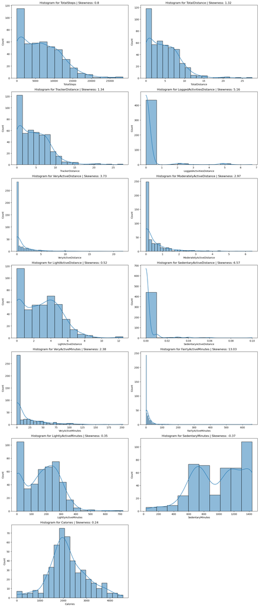

```python
import math
fitbit_df_cols = fitbit_df.columns.tolist()
fitbit_df_cols.remove('ActivityDate')

num_cols = 2  # Columns per row
num_rows = math.ceil(len(fitbit_df_cols) / num_cols)  # Dynamically calculate rows


plt.figure(figsize=(15, 5 * num_rows))  # Adjust figure size
for idx, col in enumerate(fitbit_df_cols):
    plt.subplot(num_rows, num_cols, idx + 1)
    plt.title(f"Histogram for {col} | Skewness: {round(fitbit_df[col].skew(),2)} ")
    sns.histplot(fitbit_df[col], bins='auto', cbar=True, kde=True)

plt.tight_layout()
plt.show()
```

## Bivariante analysis

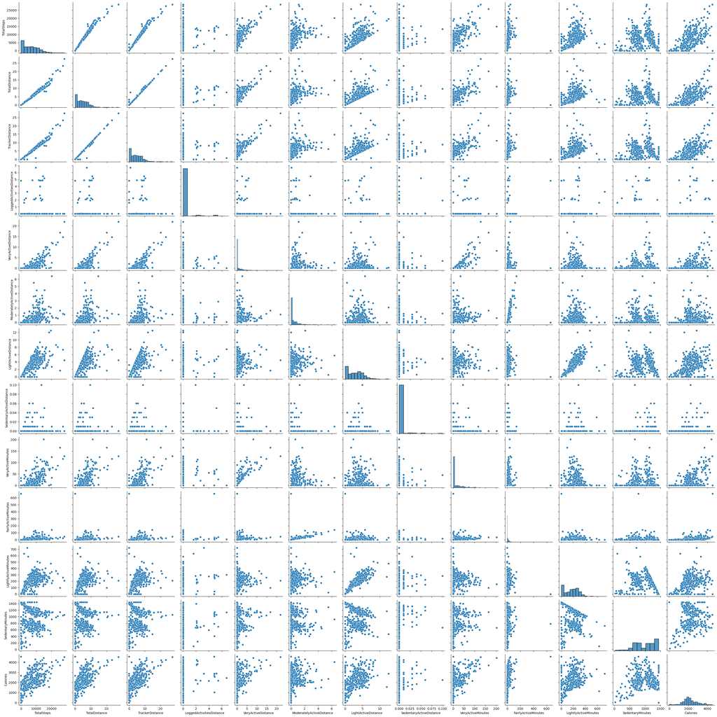

```python
sns.pairplot(fitbit_df)
plt.show()
```

1. If the plot is diagonal , histograms of kernel density plots , is shows the distribution of the individual variables.
2. If the scatter plot is in the lower triangle, it displays the relationship between the pairs of the variables.
3. If the scatter plots above and below the diagonal are mirror images, indicating symmetry.
4. If the histogram plots are more centered, it represents the locations of peaks.
5. Skewness is depicted by observing whether the histogram is symmetrical or skewed to the left or right.

## Multivariate

```python
fitbit_df[fitbit_df_cols_list].corr()
```

|  | TotalSteps | TotalDistance | TrackerDistance | LoggedActivitiesDistance | VeryActiveDistance | ModeratelyActiveDistance | LightActiveDistance | SedentaryActiveDistance | VeryActiveMinutes | FairlyActiveMinutes | LightlyActiveMinutes | SedentaryMinutes | Calories |
| --- | --- | --- | --- | --- | --- | --- | --- | --- | --- | --- | --- | --- | --- |
| TotalSteps | 1.000000 | 0.986789 | 0.982997 | 0.146380 | 0.733689 | 0.541838 | 0.775562 | 0.081965 | 0.699699 | 0.238389 | 0.654418 | -0.285258 | 0.581380 |
| TotalDistance | 0.986789 | 1.000000 | 0.995122 | 0.164312 | 0.791778 | 0.515128 | 0.744812 | 0.080787 | 0.714320 | 0.230712 | 0.614152 | -0.260301 | 0.613647 |
| TrackerDistance | 0.982997 | 0.995122 | 1.000000 | 0.094890 | 0.789353 | 0.516099 | 0.737570 | 0.077461 | 0.711804 | 0.232301 | 0.598043 | -0.258083 | 0.612066 |
| LoggedActivitiesDistance | 0.146380 | 0.164312 | 0.094890 | 1.000000 | 0.154754 | 0.060123 | 0.115671 | 0.091091 | 0.218253 | 0.231675 | 0.133856 | -0.092991 | 0.148740 |
| VeryActiveDistance | 0.733689 | 0.791778 | 0.789353 | 0.154754 | 1.000000 | 0.240440 | 0.264580 | 0.044666 | 0.854292 | 0.129528 | 0.193593 | -0.087726 | 0.434133 |
| ModeratelyActiveDistance | 0.541838 | 0.515128 | 0.516099 | 0.060123 | 0.240440 | 1.000000 | 0.326959 | 0.016350 | 0.272720 | 0.480906 | 0.291906 | -0.236723 | 0.300781 |
| LightActiveDistance | 0.775562 | 0.744812 | 0.737570 | 0.115671 | 0.264580 | 0.326959 | 1.000000 | 0.069051 | 0.276649 | 0.112307 | 0.857555 | -0.343560 | 0.451239 |
| SedentaryActiveDistance | 0.081965 | 0.080787 | 0.077461 | 0.091091 | 0.044666 | 0.016350 | 0.069051 | 1.000000 | 0.032322 | -0.003361 | 0.110162 | 0.042280 | 0.096874 |
| VeryActiveMinutes | 0.699699 | 0.714320 | 0.711804 | 0.218253 | 0.854292 | 0.272720 | 0.276649 | 0.032322 | 1.000000 | 0.167764 | 0.199697 | -0.177652 | 0.518905 |
| FairlyActiveMinutes | 0.238389 | 0.230712 | 0.232301 | 0.231675 | 0.129528 | 0.480906 | 0.112307 | -0.003361 | 0.167764 | 1.000000 | 0.095449 | -0.142598 | 0.334550 |
| LightlyActiveMinutes | 0.654418 | 0.614152 | 0.598043 | 0.133856 | 0.193593 | 0.291906 | 0.857555 | 0.110162 | 0.199697 | 0.095449 | 1.000000 | -0.393499 | 0.377249 |
| SedentaryMinutes | -0.285258 | -0.260301 | -0.258083 | -0.092991 | -0.087726 | -0.236723 | -0.343560 | 0.042280 | -0.177652 | -0.142598 | -0.393499 | 1.000000 | 0.011824 |
| Calories | 0.581380 | 0.613647 | 0.612066 | 0.148740 | 0.434133 | 0.300781 | 0.451239 | 0.096874 | 0.518905 | 0.334550 | 0.377249 | 0.011824 | 1.000000 |

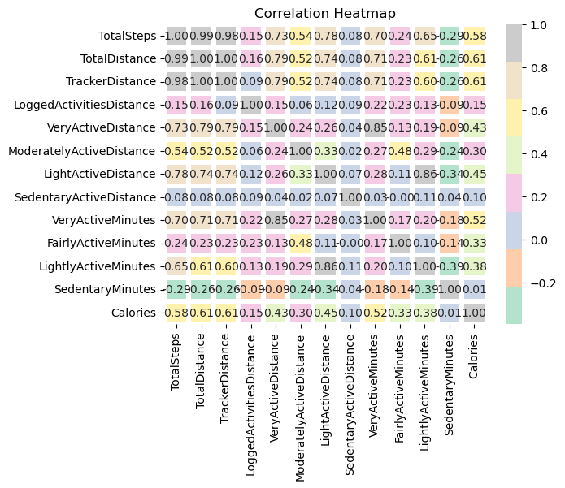

```python
sns.heatmap(fitbit_df[fitbit_df_cols_list].corr(),annot=True,fmt='.2f', cmap='Pastel2', linewidths=3)
plt.title('Correlation Heatmap')
plt.show()
```